# Statistical Modeling and Graphing

Siddhesh Shinde

2025-12-19

**Machine:** Siddheshs-MacBook-Pro.local - Darwin 25.1.0

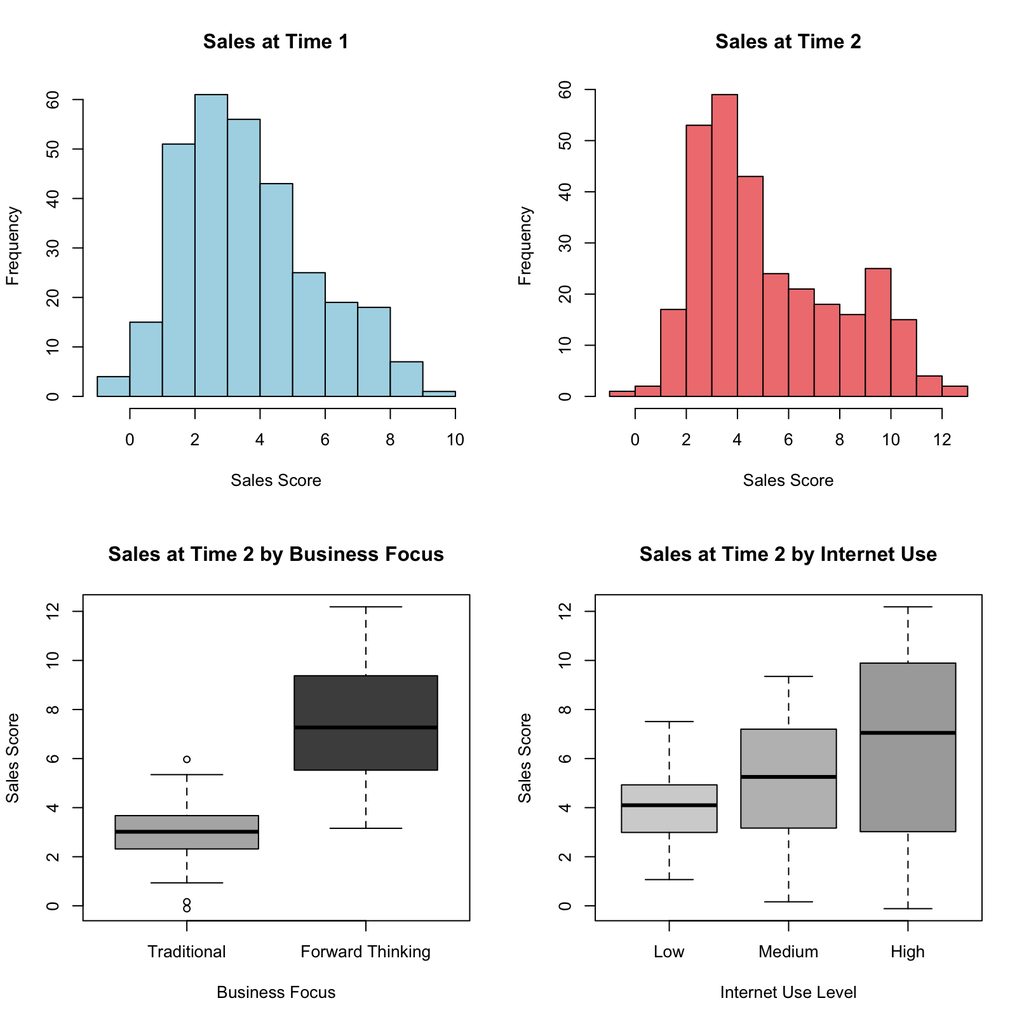

*Citation*: Trends in Internet-based business-to-business marketing

*Abstract*: The Internet is changing the transactional paradigms under which businesses-to-business marketers operate. Business-to-business marketers that take advantage of the operational efficiencies and effectiveness that emerge from utilizing the Internet in transactions are out performing firms that utilize traditional transactional processes. As an example, Dell computers, by utilizing business-to-business processes that take advantage of the Internet, has gained the largest market share in the PC business when compared to traditional manufacturers such as Compaq. This paper first examines the genesis of the Internet movement in business-to-business markets. The long-term impact of the increase of business-to-business utilization of the Internet on the marketing theory and marketing process is then discussed. Finally, managerial implications and directions for future research are highlighted.

Dataset includes:

```
1)  Business marketing focus - traditional or forward thinking.

2)  Internet use - low, medium, or high levels of business marketing use on the internet.

3)  Time _ 1 - sales scores at the first measurement time.

4)  Time _ 2 - sales scores at the second measurement time
```

On all of these questions, be sure to include a coherent label for the X and Y axes. You should change them to be “professional looking” (i.e. Proper Case, explain the variable listed, and could be printed in a journal). The following will be assessed:

```
1)  Is it readable?

2)  Is X-axis labeled appropriately?

3)  Is Y-axis labeled appropriately?

4)  Is it the right graph?

5)  Do the labels in the legend look appropriate?

6)  Are there error bars when appropriate?
```

We won’t grade for color of bars or background color, but you should consider that these things are usually printed in black/white - so be sure you know how to change those values as well as get rid of that grey background.

Please note that each subpoint (i.e. a, b) indicates a different chart.

1. Make a simple histogram using ggplot:
   1. Sales at time 1

I have used `geom_histogram()` to plot the histogram of sales at time 1 with a binwidth of 0.5 with x-axis being Sales at Time 1 and y-axis being the frequency. I have used `ggplot()` to plot the data and cleanup theme for graph.

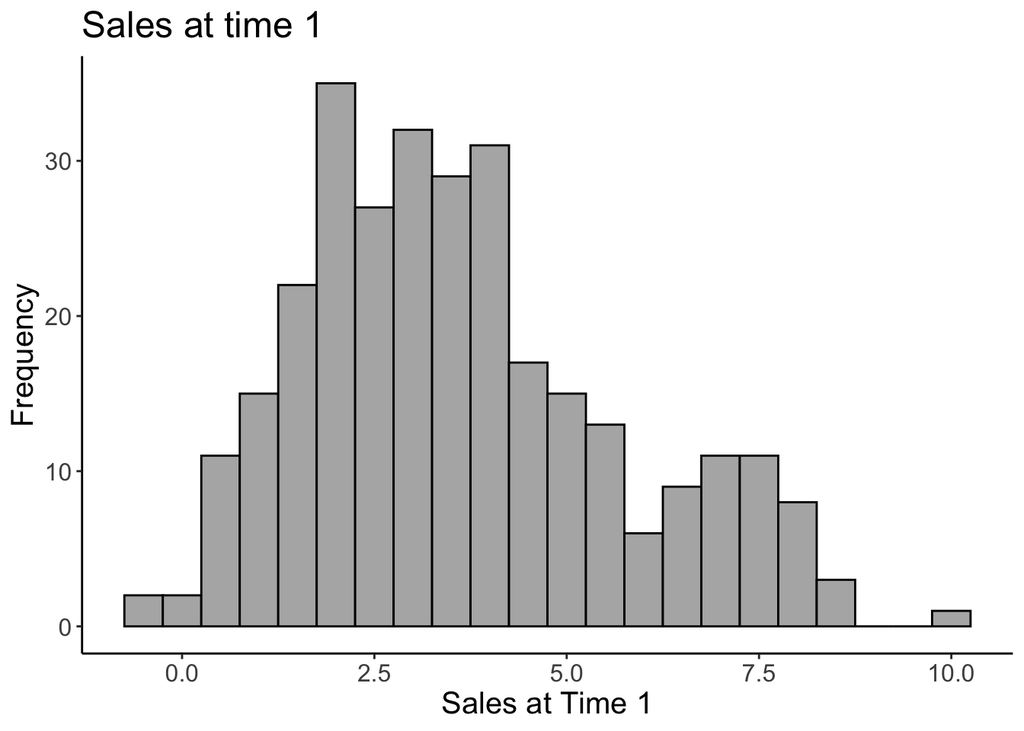

[output not shown]

```r
ggplot(labdata, aes(x = time.1)) +
  geom_histogram(binwidth = 0.5, color = "black", fill = "gray70") +
  labs(title = "Sales at time 1",
       x = "Sales at Time 1",
       y = "Frequency") +
  cleanup
```

I have used `geom_histogram()` to plot the histogram of sales at time 2 with a binwidth of 0.5 with x-axis being Sales at Time 2 and y-axis being the frequency. I have used `ggplot()` to plot the data and cleanup theme for graph.

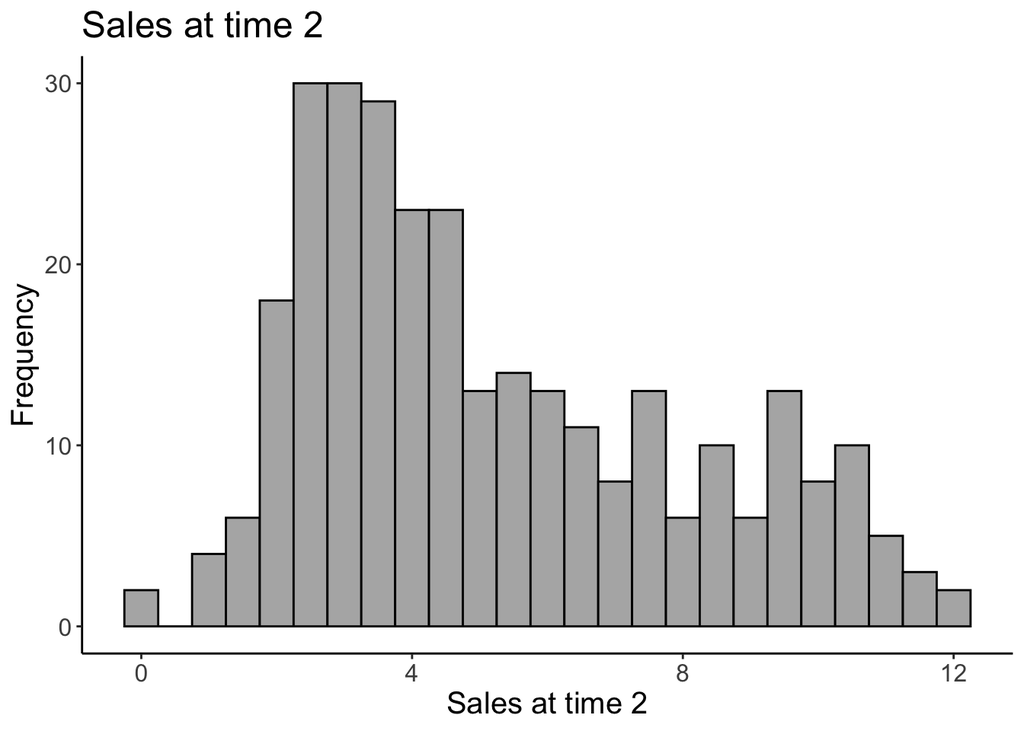

```r
ggplot(labdata, aes(x = time.2)) +
  geom_histogram(binwidth = 0.5, color = "black", fill = "gray70") +
  labs(title = "Sales at time 2",
       x = "Sales at time 2",
       y = "Frequency") +
  cleanup
```

2. Make a bar chart with two independent variables:
   1. Business focus, internet, DV: sales at time 2

I have used `ggplot()` to plot the data with the internet usage on x-axis, sales at time 2 on y-axis and fill as business focus. I have used `stat_summary()` to first calculate the mean of Sales at Time 2, internet usage and display it as bars plotted side-by-side and then to add confidence interval error.

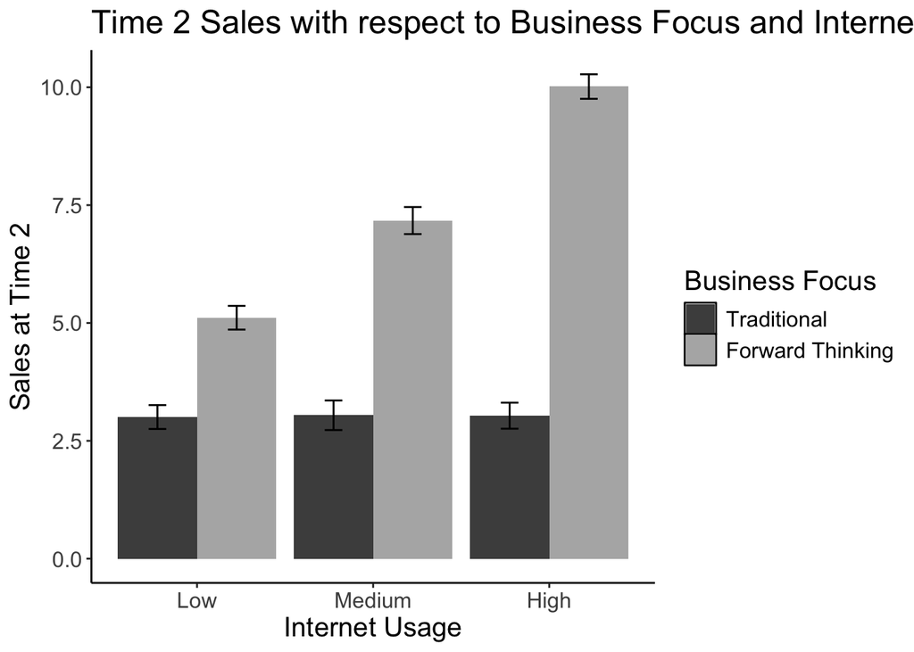

```r
bar_data <- ggplot(labdata, aes(x = internet, y = time.2, fill = biz_focus))

bar_data +
  stat_summary(fun = mean,
               geom = "bar",
               position = "dodge") +
  stat_summary(fun.data = mean_cl_normal,
               geom = "errorbar",
               position = position_dodge(width = 0.90),
               width = 0.2) +
  labs(title = "Time 2 Sales with respect to Business Focus and Internet",
       x = "Internet Usage",
       y = "Sales at Time 2") +
  cleanup +
  scale_fill_manual(values = c("gray30", "gray70"), name = "Business Focus")
```

3. Make a bar chart with two independent variables:
   1. Time (time 1, time 2), Business focus, DV: is sales from time 1 and 2

I have used `melt()` from `reshape2` package to create a new `Time` variable to combine time 1 and time 2. Used `factor()` to set levels as required. Then I have used `ggplot()` to plot the data with the Time period on x-axis, sales on y-axis and fill as business focus. I have used `stat_summary()` to first calculate the mean of sales, time period and display it as bars plotted side-by-side and then to add confidence interval error.

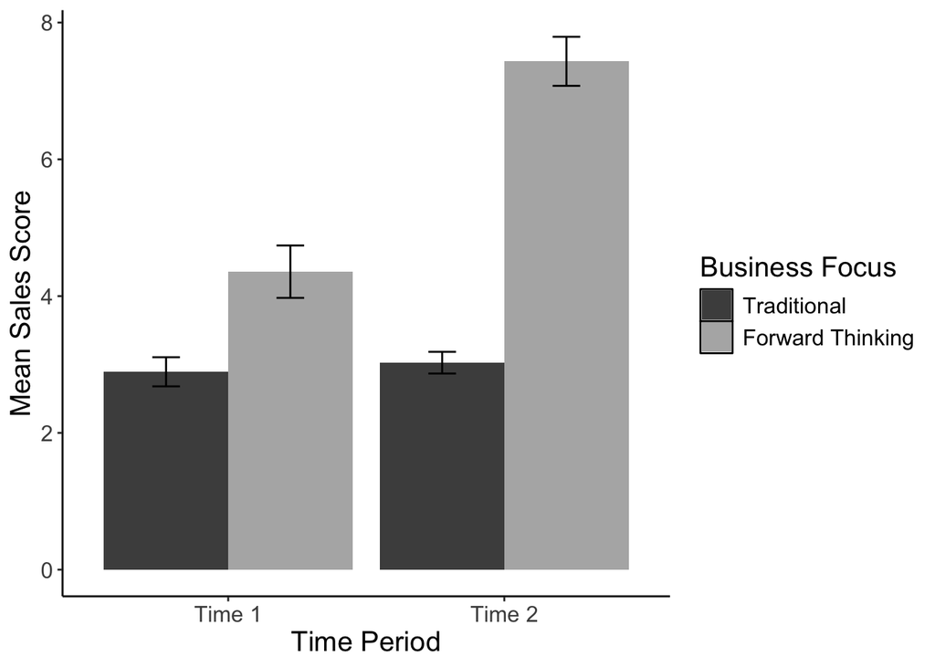

```r
library(reshape2)

long_data <- melt(labdata,
                  id.vars = c("id", "biz_focus", "internet"),
                  measure.vars = c("time.1", "time.2"),
                  variable.name = "Time",
                  value.name = "Sales")

long_data$Time <- factor(long_data$Time,
                         levels = c("time.1", "time.2"),
                         labels = c("Time 1", "Time 2"))

# Create the bar chart
time_bar <- ggplot(long_data, aes(x = Time, y = Sales, fill = biz_focus))

time_bar +
  stat_summary(fun = mean,
               geom = "bar",
               position = "dodge") +
  stat_summary(fun.data = mean_cl_normal,
               geom = "errorbar",
               position = position_dodge(width = 0.90),
               width = 0.2) +
  labs(x = "Time Period",
       y = "Mean Sales Score") +
  cleanup +
  scale_fill_manual(values = c("gray30", "gray70"), name = "Business Focus")
```

4. Make a simple line graph:
   1. Time (time 1, time 2), DV: is sales from time 1 and 2

I have used `long_data` with `Time` variable calculated above and `ggplot()` to plot the data. I have used `stat_summary()` to calculate mean of Time on x-axis as a line and points. I have also added add confidence interval error.

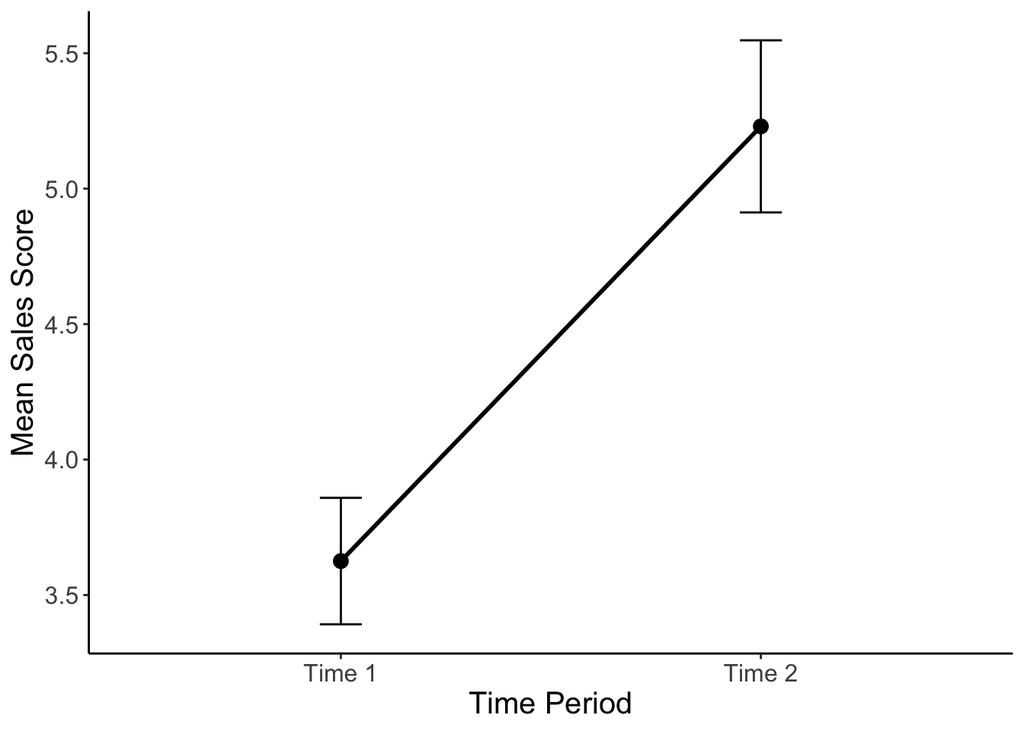

```r
ggplot(long_data, aes(x = Time, y = Sales, group = 1)) +
  stat_summary(fun = mean,
               geom = "line",
               size = 1) +
  stat_summary(fun = mean,
               geom = "point",
               size = 3) +
  stat_summary(fun.data = mean_cl_normal,
               geom = "errorbar",
               width = 0.1) +
  labs(x = "Time Period",
       y = "Mean Sales Score") +
  cleanup
```

5. Make a simple scatterplot:
   1. Sales at Time 1, Time 2

I have used `geom_point()` to create scatter points with size 2 and alpha 0.6 for transparency. Then I have used `geom_smooth()` to add a linear regression line to show the trend. se = FALSE removes the confidence band around the line.

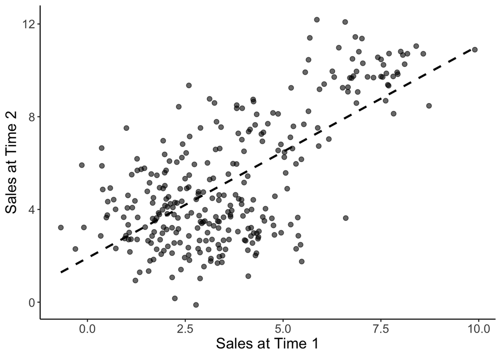

```r
ggplot(labdata, aes(x = time.1, y = time.2)) +
  geom_point(size = 2, alpha = 0.6) +
  geom_smooth(method = "lm", se = FALSE, color = "black", linetype = "dashed") +
  labs(x = "Sales at Time 1",
       y = "Sales at Time 2") +
  cleanup
```

6. Make a grouped scatterplot:
   1. Sales at time 1 and 2, Business focus

I have used `geom_point()` to create scatter points with size 2.5 and alpha 0.7 for transparency. I have used `scale_shape_manual()` to use values 16 for filled circle and 1 for empty circle to indicate Business Focus data points.

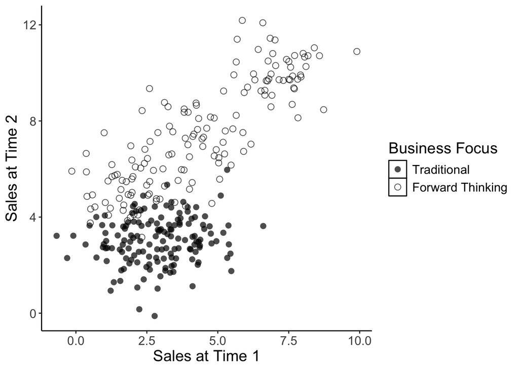

```r
ggplot(labdata, aes(x = time.1, y = time.2, shape = biz_focus)) +
  geom_point(size = 2.5, alpha = 0.7) +
  scale_shape_manual(values = c(16, 1), name = "Business Focus") +
  labs(x = "Sales at Time 1",
       y = "Sales at Time 2") +
  cleanup
```